# Data Mining - Project 1

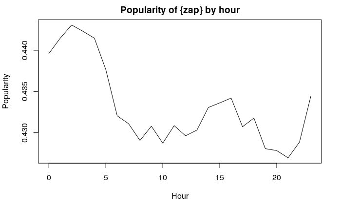

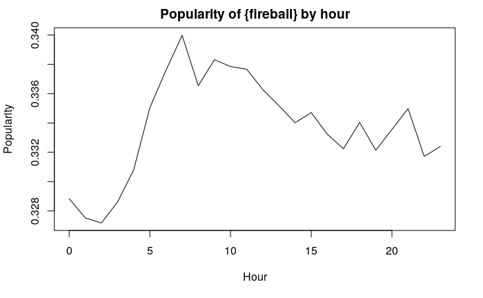

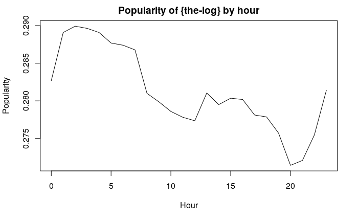

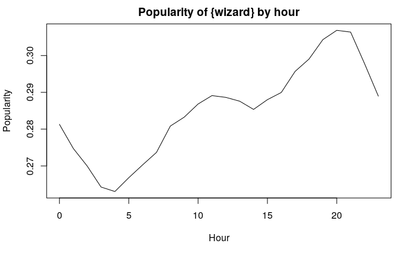

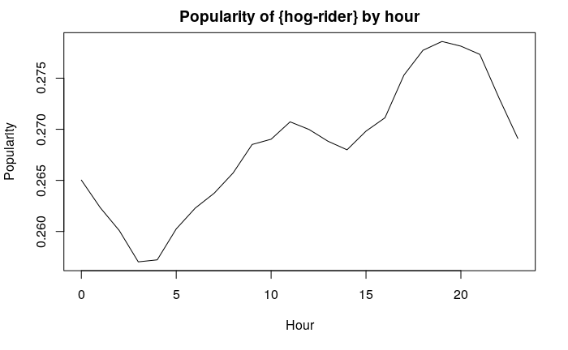

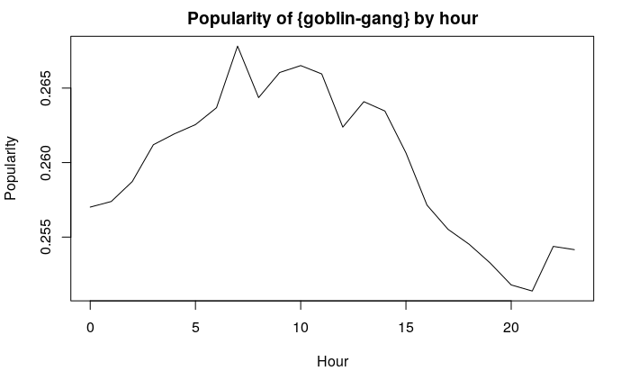

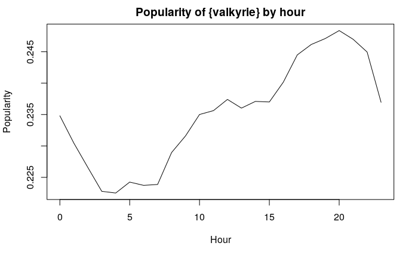

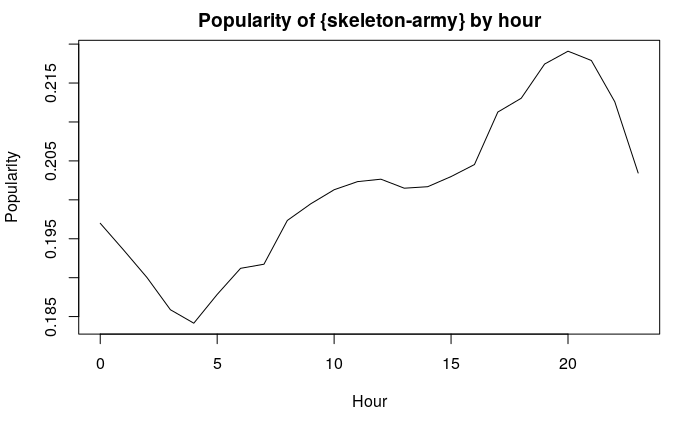

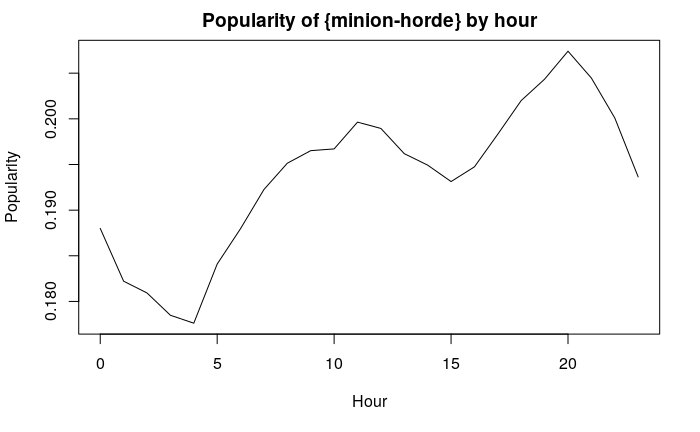

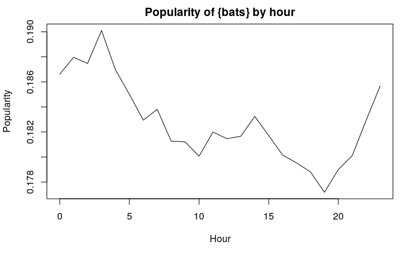

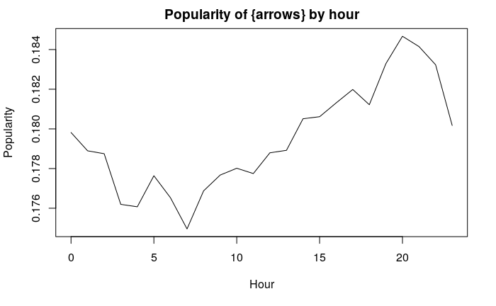

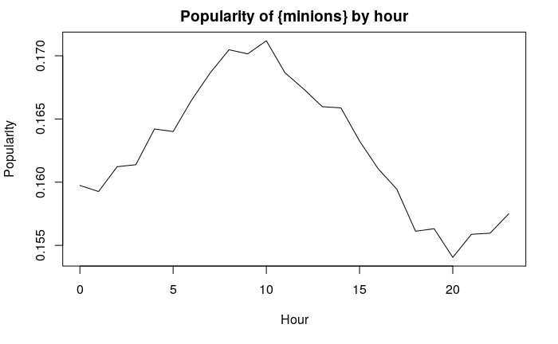

[8 more figures not shown]

```r
for (i in 1:20) {
  plot(0:23, as.numeric(result[i,2:25][,]), type="l", xlab="Hour", ylab="Popularity", main=sprintf("Popularity of %s by hour", as.character(result[i, 1])))
}
```

```r
remove(transactionsOfHour, frequentItemSetsOfHour, result)
```

It seems that some cards gain popularity in the busiest times of the day, when most casual players are playing (15:00-00:00), e.g. *wizard*, *hog-rider* or *valkyrie*. Similarly, there are cards with the lowest popularity in those hours, e.g. *the-log*, *goblin-gang* or *bats*.

### Cards association rules

Using apriori algorithm, we can also look for some interesting association rules.

In the beginning, let’s look at the best rules in terms of lift, for any set size, with support at least $0.01$ and confidence at least $0.7$.

```r
minSupport = 0.01

frequentItemSets = apriori(get_transactions(games), parameter = list(supp = minSupport, minlen = 2, maxlen = 8, target = "frequent itemsets"), appearance = NULL, control = list(verbose = FALSE))
rules = ruleInduction(frequentItemSets, get_transactions(games), confidence = 0.7, control = list(method = "apriori", verbose = FALSE))
rules = sort(rules, decreasing = TRUE, by = "lift")
inspect(head(rules, n = 100))
```

|  | lhs |  | rhs | support | confidence | lift | count |
| --- | --- | --- | --- | --- | --- | --- | --- |
| [1] | {fireball,ice-golem,ice-spirit,musketeer} | => | {cannon} | 0.0100014 | 0.9242669 | 34.60637 | 100014 |
| [2] | {hog-rider,ice-spirit,musketeer,skeletons,the-log} | => | {cannon} | 0.0100122 | 0.9180199 | 34.37247 | 100122 |
| [3] | {hog-rider,ice-golem,ice-spirit,musketeer} | => | {cannon} | 0.0100827 | 0.9131722 | 34.19096 | 100827 |
| [4] | {fireball,hog-rider,ice-spirit,musketeer,skeletons} | => | {cannon} | 0.0103163 | 0.9105055 | 34.09111 | 103163 |
| [5] | {fireball,hog-rider,musketeer,skeletons,the-log} | => | {cannon} | 0.0100523 | 0.9094306 | 34.05087 | 100523 |
| [6] | {ice-spirit,musketeer,skeletons,the-log} | => | {cannon} | 0.0101104 | 0.9091105 | 34.03888 | 101104 |
| [7] | {fireball,ice-spirit,musketeer,skeletons} | => | {cannon} | 0.0104042 | 0.9057685 | 33.91375 | 104042 |
| [8] | {ice-golem,ice-spirit,musketeer} | => | {cannon} | 0.0101836 | 0.9020178 | 33.77332 | 101836 |
| [9] | {fireball,musketeer,skeletons,the-log} | => | {cannon} | 0.0101328 | 0.8990231 | 33.66119 | 101328 |
| [10] | {hog-rider,ice-golem,skeletons} | => | {cannon} | 0.0100019 | 0.8973131 | 33.59716 | 100019 |

[output cut: 90 more lines]

#### Cannon, Musketeer and Skeletons

Most of our rules are with *cannon* card on the right side and some recurring cards on the left side. Our sets on the left side are quite big, so it’s hard to reason about it. Let’s look closer into it by allowing only sets of size 2 to be on the left side.

```r
minSupport = 0.01

rules = apriori(get_transactions(games), parameter = list(supp = minSupport, conf = 0.5, minlen = 1, maxlen = 3, target = "rules"),
                control = list(sort = -1, verbose = FALSE),
                appearance = list(rhs = "cannon"))
rules = sort(rules, decreasing = TRUE, by = "lift")

inspect(head(rules, n = 10))
```

|  | lhs |  | rhs | support | confidence | lift | count |
| --- | --- | --- | --- | --- | --- | --- | --- |
| [1] | {musketeer,skeletons} | => | {cannon} | 0.0112167 | 0.7934623 | 29.70879 | 112167 |
| [2] | {ice-golem,musketeer} | => | {cannon} | 0.0106302 | 0.7646416 | 28.62968 | 106302 |
| [3] | {hog-rider,skeletons} | => | {cannon} | 0.0116828 | 0.6509793 | 24.37394 | 116828 |
| [4] | {ice-spirit,musketeer} | => | {cannon} | 0.0116417 | 0.6415043 | 24.01918 | 116417 |
| [5] | {ice-golem,skeletons} | => | {cannon} | 0.0101299 | 0.5494839 | 20.57376 | 101299 |
| [6] | {ice-golem,ice-spirit} | => | {cannon} | 0.0104009 | 0.5203754 | 19.48388 | 104009 |

```r
plot(head(rules, n = 10), data = games, method="graph", engine="htmlwidget", shading = "lift")
```

[interactive chart not shown]

We see that *musketeer*, *skeletons* are cards that are often being complemented with *cannon*. We could speculate that it’s because these cards have good synergy or *cannon* helps to unleash the full potential of *musketeer*, *skeletons*. But is this relation symetrical? Let’s check rules, where only *musketeer* is allowed on the right side.

```r
minSupport = 0.01

rules = apriori(get_transactions(games), parameter = list(supp = minSupport, conf = 0.5, minlen = 1, maxlen = 3, target = "rules"),
                control = list(sort = -1, verbose = FALSE),
                appearance = list(rhs = "musketeer"))
rules = sort(rules, decreasing = TRUE, by = "lift")

inspect(head(rules, n = 10))
```

|  | lhs |  | rhs | support | confidence | lift | count |
| --- | --- | --- | --- | --- | --- | --- | --- |
| [1] | {cannon,ice-golem} | => | {musketeer} | 0.0106302 | 0.9413505 | 9.217233 | 106302 |
| [2] | {cannon,skeletons} | => | {musketeer} | 0.0112167 | 0.9233980 | 9.041451 | 112167 |
| [3] | {cannon,ice-spirit} | => | {musketeer} | 0.0116417 | 0.8832920 | 8.648753 | 116417 |
| [4] | {cannon,the-log} | => | {musketeer} | 0.0118973 | 0.7900406 | 7.735682 | 118973 |
| [5] | {cannon,hog-rider} | => | {musketeer} | 0.0136406 | 0.7226731 | 7.076054 | 136406 |
| [6] | {hog-rider,skeletons} | => | {musketeer} | 0.0129290 | 0.7204190 | 7.053983 | 129290 |
| [7] | {cannon,fireball} | => | {musketeer} | 0.0130438 | 0.7015511 | 6.869238 | 130438 |
| [8] | {ice-golem,skeletons} | => | {musketeer} | 0.0107756 | 0.5845091 | 5.723220 | 107756 |
| [9] | {cannon} | => | {musketeer} | 0.0151810 | 0.5684065 | 5.565552 | 151810 |
| [10] | {ice-golem,ice-spirit} | => | {musketeer} | 0.0112898 | 0.5648487 | 5.530716 | 112898 |

```r
plot(head(rules, n = 10), data = games, method="graph", engine="htmlwidget", shading = "lift")
```

[interactive chart not shown]

It turns out that *cannon* is in most of the best sets that implicate *musketeer*, so the relation seems to be symetrical. Let’s check the same for *skeletons*.

```r
minSupport = 0.01

rules = apriori(get_transactions(games), parameter = list(supp = minSupport, conf = 0.5, minlen = 1, maxlen = 3, target = "rules"),
                control = list(sort = -1, verbose = FALSE),
                appearance = list(rhs = "skeletons"))
rules = sort(rules, decreasing = TRUE, by = "lift")

inspect(head(rules, n = 10))
```

|  | lhs |  | rhs | support | confidence | lift | count |
| --- | --- | --- | --- | --- | --- | --- | --- |
| [1] | {cannon,ice-golem} | => | {skeletons} | 0.0101299 | 0.8970467 | 22.98334 | 101299 |
| [2] | {cannon,ice-spirit} | => | {skeletons} | 0.0111632 | 0.8469867 | 21.70075 | 111632 |
| [3] | {ice-golem,ice-spirit} | => | {skeletons} | 0.0157716 | 0.7890811 | 20.21714 | 157716 |
| [4] | {ice-golem,musketeer} | => | {skeletons} | 0.0107756 | 0.7751003 | 19.85894 | 107756 |
| [5] | {cannon,musketeer} | => | {skeletons} | 0.0112167 | 0.7388644 | 18.93053 | 112167 |
| [6] | {cannon,the-log} | => | {skeletons} | 0.0107744 | 0.7154744 | 18.33125 | 107744 |
| [7] | {ice-spirit,musketeer} | => | {skeletons} | 0.0120858 | 0.6659760 | 17.06305 | 120858 |
| [8] | {fireball,ice-golem} | => | {skeletons} | 0.0161224 | 0.6631894 | 16.99166 | 161224 |
| [9] | {ice-golem,the-log} | => | {skeletons} | 0.0169409 | 0.6245493 | 16.00165 | 169409 |
| [10] | {cannon,hog-rider} | => | {skeletons} | 0.0116828 | 0.6189497 | 15.85819 | 116828 |

```r
plot(head(rules, n = 10), data = games, method="graph", engine="htmlwidget", shading = "lift")
```

[interactive chart not shown]

#### Tornado and Executioner

Another interesting association that can be observed is the synergy between *tornado* and *executioner*.

```r
minSupport = 0.001

rules = apriori(get_transactions(games), parameter = list(supp = minSupport, conf = 0.5, minlen = 1, maxlen = 3, target = "rules"),
                control = list(sort = -1, verbose = FALSE),
                appearance = list(rhs = "executioner"))
rules = sort(rules, decreasing = TRUE, by = "lift")

inspect(head(rules, n = 10))
```

|  | lhs |  | rhs | support | confidence | lift | count |
| --- | --- | --- | --- | --- | --- | --- | --- |
| [1] | {goblins,tornado} | => | {executioner} | 0.0030623 | 0.6702342 | 7.623427 | 30623 |
| [2] | {ice-spirit,tornado} | => | {executioner} | 0.0066374 | 0.5627538 | 6.400916 | 66374 |
| [3] | {hog-rider,tornado} | => | {executioner} | 0.0156799 | 0.5106062 | 5.807775 | 156799 |

```r
plot(head(rules, n = 10), data = games, method="graph", engine="htmlwidget", shading = "lift")
```

[interactive chart not shown]

We see that *tornado* often implies *executioner*. It matches with internet guides that emphasise synergy of *tornado* and *executioner*. In every recommended deck with *executioner* there is also *tornado*.